# Practical Machine Learning Week 4

Brittany

2/6/2019

## Background

Using devices such as Jawbone Up, Nike FuelBand, and Fitbit it is now possible to collect a large amount of data about personal activity relatively inexpensively. These type of devices are part of the quantified self movement - a group of enthusiasts who take measurements about themselves regularly to improve their health, to find patterns in their behavior, or because they are tech geeks. One thing that people regularly do is quantify how much of a particular activity they do, but they rarely quantify how well they do it. In this project, your goal will be to use data from accelerometers on the belt, forearm, arm, and dumbell of 6 participants. They were asked to perform barbell lifts correctly and incorrectly in 5 different ways. More information is available from the website here: http://web.archive.org/web/20161224072740/http:/groupware.les.inf.puc-rio.br/har

## Setup

```r
library(caret)
```

```r
library(rpart)
library(rpart.plot)
library(RColorBrewer)
library(rattle)
library(randomForest)
library(knitr)
library(e1071)
set.seed(123)

testing<-read.csv("~/Desktop/pml-testing.csv")
original<-read.csv("~/Desktop/pml-training.csv")
```

## Methodology

```r
# clean the data
# str(original)
removing <- which(colSums(is.na(original) | original=="") > 0.95*dim(original)[1])
original <- original[,-removing]
original <- original[,-c(1:7)]
testing <- testing[,-removing]
testing <- testing[,-c(1:7)]

# split into 70% training and 30% validation
set.seed(123)
original$split <- runif(19622,min=0,max=1)
training<-original [which(original$split <= 0.70),]
validation<-original [which(original$split > 0.70),]
training <- training[,-54]
validation <- validation[,-54]
```

# Decision Tree

Now, the first model, Decision Tree. This gets us an accuracy of 49.2% with 5 folds. Not great.

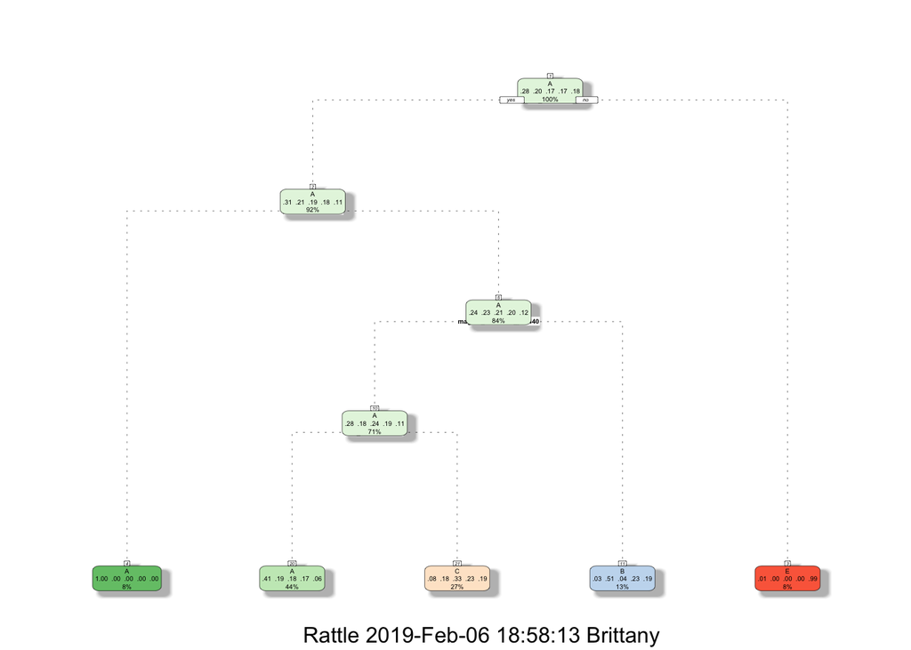

```r
cv <- trainControl(method="cv",number=5)
model1 <- train(classe ~ .,data=training, method="rpart",trControl=cv)
fancyRpartPlot(model1$finalModel, cex=0.3)
```

```r
# Confusion Matrix
predict1 <- predict(model1, validation, type="raw")
conftree1 <- confusionMatrix(predict1, validation$classe)
conftree1
```

```
## Confusion Matrix and Statistics
##
##           Reference
## Prediction    A    B    C    D    E
##          A 1510  450  496  434  174
##          B   27  376   36  149  146
##          C  122  274  511  354  283
##          D    0    0    0    0    0
##          E    5    0    0    0  467
##
## Overall Statistics
##
##                Accuracy : 0.4926
##                  95% CI : (0.4797, 0.5055)
##     No Information Rate : 0.2862
##     P-Value [Acc > NIR] : < 2.2e-16
##
##                   Kappa : 0.3347
##  Mcnemar's Test P-Value : NA
##
## Statistics by Class:
##
##                      Class: A Class: B Class: C Class: D Class: E
## Sensitivity            0.9075  0.34182  0.48993   0.0000  0.43645
## Specificity            0.6255  0.92406  0.78348   1.0000  0.99895
## Pos Pred Value         0.4928  0.51226  0.33096      NaN  0.98941
## Neg Pred Value         0.9440  0.85748  0.87541   0.8388  0.88712
## Prevalence             0.2862  0.18920  0.17939   0.1612  0.18404
## Detection Rate         0.2597  0.06467  0.08789   0.0000  0.08032
## Detection Prevalence   0.5270  0.12625  0.26557   0.0000  0.08118
## Balanced Accuracy      0.7665  0.63294  0.63671   0.5000  0.71770
```

```r
conftree1$overall[1]
```

```
##  Accuracy
## 0.4926041
```

## Random Forests

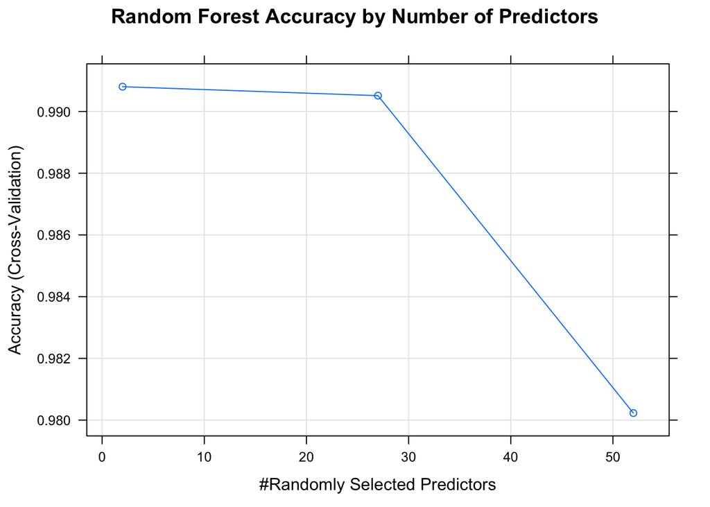

```r
model2 <- train(classe ~ ., data=training,method="rf",trControl=cv)
plot(model2,main="Random Forest Accuracy by Number of Predictors")
```

```r
print(model2)
```

```
## Random Forest
##
## 13808 samples
##    52 predictor
##     5 classes: 'A', 'B', 'C', 'D', 'E'
##
## No pre-processing
## Resampling: Cross-Validated (5 fold)
## Summary of sample sizes: 11047, 11045, 11045, 11046, 11049
## Resampling results across tuning parameters:
##
##   mtry  Accuracy   Kappa
##    2    0.9908027  0.9883664
##   27    0.9905115  0.9879979
##   52    0.9802278  0.9749904
##
## Accuracy was used to select the optimal model using the largest value.
## The final value used for the model was mtry = 2.
```

```r
predict2 <- predict(model2, validation)
conftree2 <- confusionMatrix(predict2, validation$classe)
conftree2
```

```
## Confusion Matrix and Statistics
##
##           Reference
## Prediction    A    B    C    D    E
##          A 1662    6    0    0    0
##          B    2 1094    5    0    0
##          C    0    0 1036   16    2
##          D    0    0    2  918    0
##          E    0    0    0    3 1068
##
## Overall Statistics
##
##                Accuracy : 0.9938
##                  95% CI : (0.9914, 0.9957)
##     No Information Rate : 0.2862
##     P-Value [Acc > NIR] : < 2.2e-16
##
##                   Kappa : 0.9922
##  Mcnemar's Test P-Value : NA
##
## Statistics by Class:
##
##                      Class: A Class: B Class: C Class: D Class: E
## Sensitivity            0.9988   0.9945   0.9933   0.9797   0.9981
## Specificity            0.9986   0.9985   0.9962   0.9996   0.9994
## Pos Pred Value         0.9964   0.9936   0.9829   0.9978   0.9972
## Neg Pred Value         0.9995   0.9987   0.9985   0.9961   0.9996
## Prevalence             0.2862   0.1892   0.1794   0.1612   0.1840
## Detection Rate         0.2859   0.1882   0.1782   0.1579   0.1837
## Detection Prevalence   0.2869   0.1894   0.1813   0.1582   0.1842
## Balanced Accuracy      0.9987   0.9965   0.9948   0.9897   0.9987
```

```r
conftree2$overall[1]
```

```
## Accuracy
## 0.993808
```

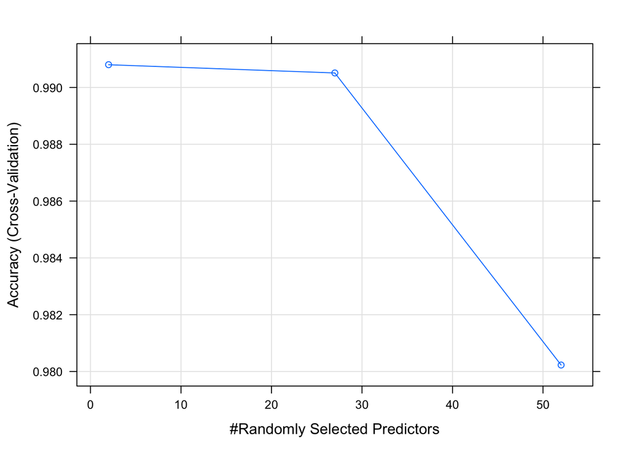

```r
plot(model2)
```

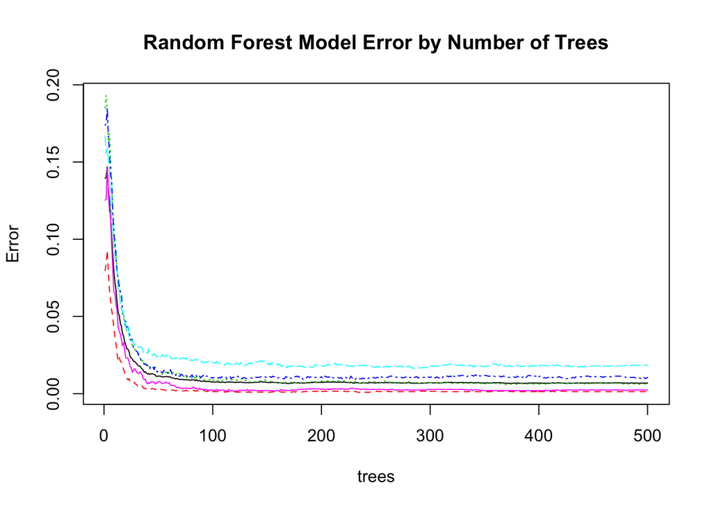

```r
plot(model2$finalModel,main="Random Forest Model Error by Number of Trees")
```

## Gradient Boosting

Finally, we will try gradient boosting. This gives us an accuracy of 96.6% with 5 folds. Although this is high, Random Forest seems to provide us the best model for predicting exercise type.

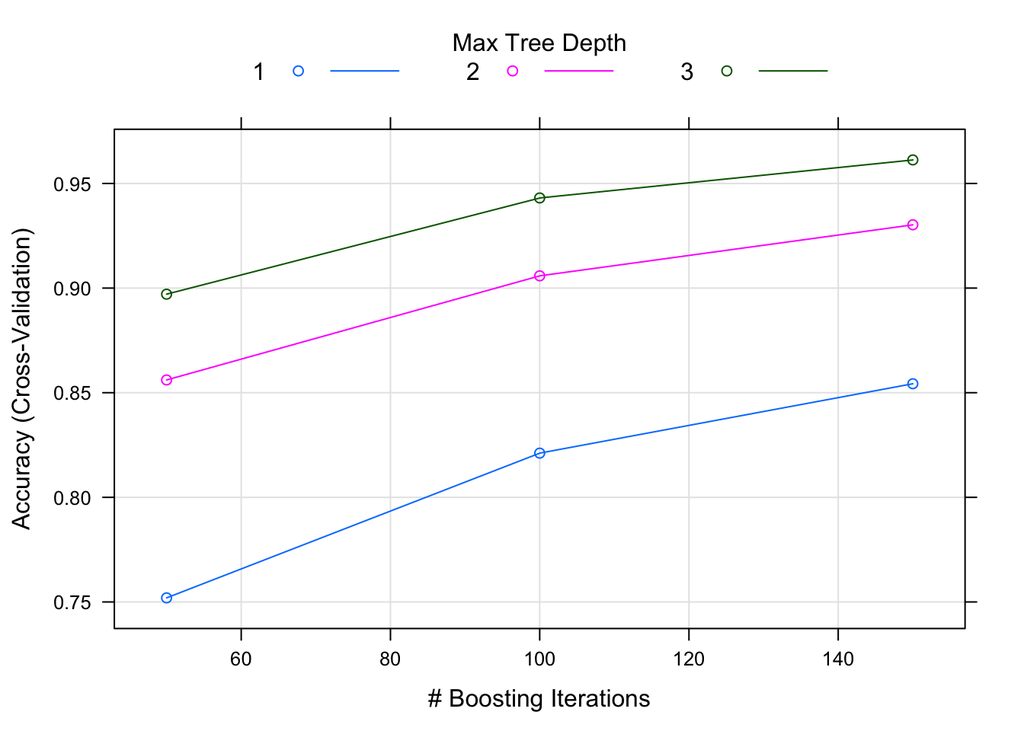

```r
model3 <- train(classe ~ ., data=training, method="gbm",trControl=cv,verbose=FALSE)
plot(model3)
```

```r
predict3 <- predict(model3, validation)
conftree3 <- confusionMatrix(predict3, validation$classe)
conftree3
```

```
## Confusion Matrix and Statistics
##
##           Reference
## Prediction    A    B    C    D    E
##          A 1638   35    0    0    1
##          B   14 1039   25    5    4
##          C    6   24 1012   39    9
##          D    6    0    5  878    7
##          E    0    2    1   15 1049
##
## Overall Statistics
##
##                Accuracy : 0.9659
##                  95% CI : (0.961, 0.9705)
##     No Information Rate : 0.2862
##     P-Value [Acc > NIR] : < 2.2e-16
##
##                   Kappa : 0.9569
##  Mcnemar's Test P-Value : 8.677e-10
##
## Statistics by Class:
##
##                      Class: A Class: B Class: C Class: D Class: E
## Sensitivity            0.9844   0.9445   0.9703   0.9370   0.9804
## Specificity            0.9913   0.9898   0.9837   0.9963   0.9962
## Pos Pred Value         0.9785   0.9558   0.9284   0.9799   0.9831
## Neg Pred Value         0.9937   0.9871   0.9934   0.9880   0.9956
## Prevalence             0.2862   0.1892   0.1794   0.1612   0.1840
## Detection Rate         0.2817   0.1787   0.1741   0.1510   0.1804
## Detection Prevalence   0.2879   0.1870   0.1875   0.1541   0.1835
## Balanced Accuracy      0.9879   0.9672   0.9770   0.9667   0.9883
```

```r
conftree3$overall[1]
```

```
##  Accuracy
## 0.9659443
```

## Conclusion

Random Forest is the best model.

```r
finalpred <- predict(model2, testing)
finalpred
```

```
##  [1] B A B A A E D B A A B C B A E E A B B B
## Levels: A B C D E
```